# Lab 4 - Coffee Lovers Unite

Author

Austin Liu

# Data Import and Packages

```python
import pandas as pd
import re
from bs4 import BeautifulSoup
import requests
```

# Question 1

## Starbucks

```python
starbucks = requests.get("https://www.menuism.com/restaurant-locations/starbucks-coffee-39564")
soup = BeautifulSoup(starbucks.content, "html.parser")

SBrows = []

for location in soup.find_all("li", attrs={"class": ""})[17:68]:
    cells = location.find_all("a")

    name_tag = cells[0]
    nametext = name_tag.text
    namelist = nametext.split(" ")

    if len(namelist) == 5:
        name = namelist[0]
        number = namelist[4]
    elif len(namelist) == 6:
        name = namelist[0] + " " + namelist[1]
        number = namelist[5]
    else:
        name = namelist[0] + " " + namelist[1] + " " + namelist[2]
        number = namelist[6]
    number = number.replace("(", "")
    number = number.replace(")", "")

    SBrows.append({
        "Name": name,
        "Number": number
    })
```

## Dunkin Donuts

```python
dunkin = requests.get("https://www.menuism.com/restaurant-locations/dunkin-donuts-181624/us")
soup2 = BeautifulSoup(dunkin.content, "html.parser")

DDrows = []

for location in soup2.find_all("li", attrs={"class": ""})[18:62]:
    cells = location.find_all("a")

    name_tag = cells[0]
    nametext = name_tag.text
    namelist = nametext.split(" ")


    if len(namelist) == 5:
        name = namelist[0]
        number = namelist[4]
    elif len(namelist) == 6:
        name = namelist[0] + " " + namelist[1]
        number = namelist[5]
    else:
        name = namelist[0] + " " + namelist[1] + " " + namelist[2]
        number = namelist[6]

    number = number.replace("(", "")
    number = number.replace(")", "")

    DDrows.append({
        "name": name,
        "number": number
    })
```

## Peet’s Coffee

```python
peets = requests.get("https://www.menuism.com/restaurant-locations/peets-coffee-tea-84051")
soup3 = BeautifulSoup(peets.content, "html.parser")

PCrows = []

for location in soup3.find_all("li", attrs={"class": ""})[17:26]:
    cells = location.find_all("a")

    name_tag = cells[0]
    nametext = name_tag.text
    namelist = nametext.split(" ")

    if len(namelist) == 7:
        name = namelist[0]
        number = namelist[6]
    else:
        name = namelist[0] + " " + namelist[1] + " " + namelist[2]
        number = namelist[5]

    number = number.replace("(", "")
    number = number.replace(")", "")

    PCrows.append({
        "Name": name,
        "Number": number
    })
```

## Tim Hortons

```python
tim = requests.get("https://www.menuism.com/restaurant-locations/tim-hortons-190025")
soup4 = BeautifulSoup(tim.content, "html.parser")
```

```python
THrows = []

for location in soup4.find_all("li", attrs={"class": ""})[17:32]:
    cells = location.find_all("a")

    name_tag = cells[0]
    nametext = name_tag.text
    namelist = nametext.split(" ")

    if len(namelist) == 7:
        name = namelist[0]
        number = namelist[6]
    else:
        name = namelist[0] + " " + namelist[1] + " " + namelist[2]
        number = namelist[5]

    number = number.replace("(", "")
    number = number.replace(")", "")

    THrows.append({
        "Name": name,
        "Number": number
    })
```

## Panera Bread

```python
panera = requests.get("https://www.menuism.com/restaurant-locations/panera-bread-4258")
soup5 = BeautifulSoup(panera.content, "html.parser")
```

```python
PBrows = []

for location in soup5.find_all("li", attrs={"class": ""})[17:32]:
    cells = location.find_all("a")

    name_tag = cells[0]
    nametext = name_tag.text
    namelist = nametext.split(" ")

    if len(namelist) == 7:
        name = namelist[0]
        number = namelist[6]
    else:
        name = namelist[0] + " " + namelist[1] + " " + namelist[2]
        number = namelist[5]

    number = number.replace("(", "")
    number = number.replace(")", "")

    PBrows.append({
        "Name": name,
        "Number": number
    })
```

## Caribou Coffee

```python
caribou = requests.get("https://www.menuism.com/restaurant-locations/caribou-coffee-164861")
soup6 = BeautifulSoup(caribou.content, "html.parser")
```

```python
CCrows = []

for location in soup6.find_all("li", attrs={"class": ""})[17:36]:
    cells = location.find_all("a")

    name_tag = cells[0]
    nametext = name_tag.text
    namelist = nametext.split(" ")

    if len(namelist) == 7:
        name = namelist[0]
        number = namelist[6]
    else:
        name = namelist[0] + " " + namelist[1] + " " + namelist[2]
        number = namelist[5]

    number = number.replace("(", "")
    number = number.replace(")", "")

    CCrows.append({
        "Name": name,
        "Number": number
    })
```

## Au Bon Pain

```python
abp = requests.get("https://www.menuism.com/restaurant-locations/au-bon-pain-69342")
soup7 = BeautifulSoup(abp.content, "html.parser")
```

```python
ABProws = []

for location in soup7.find_all("li", attrs={"class": ""})[17:38]:
    cells = location.find_all("a")

    name_tag = cells[0]
    nametext = name_tag.text
    namelist = nametext.split(" ")

    if len(namelist) == 7:
        name = namelist[0]
        number = namelist[6]
    else:
        name = namelist[0] + " " + namelist[1] + " " + namelist[2]
        number = namelist[5]

    number = number.replace("(", "")
    number = number.replace(")", "")

    ABProws.append({
        "Name": name,
        "Number": number
    })
```

## The Coffee Bean & Tea Leaf

```python
CofTea = requests.get("https://www.menuism.com/restaurant-locations/the-coffee-bean-tea-leaf-165988")
soup8 = BeautifulSoup(CofTea.content, "html.parser")
```

```python
CBTLrows = []

for location in soup8.find_all("li", attrs={"class": ""})[17:23]:
    cells = location.find_all("a")

    name_tag = cells[0]
    nametext = name_tag.text
    namelist = nametext.split(" ")

    if len(namelist) == 7:
        name = namelist[0]
        number = namelist[6]
    else:
        name = namelist[0] + " " + namelist[1] + " " + namelist[2]
        number = namelist[5]

    number = number.replace("(", "")
    number = number.replace(")", "")

    CBTLrows.append({
        "Name": name,
        "Number": number
    })
```

# McDonald’s

```python
mcdonald = requests.get("https://www.menuism.com/restaurant-locations/mcdonalds-21019")
soup9 = BeautifulSoup(mcdonald.content, "html.parser")
```

```python
MCDrows = []

for location in soup9.find_all("li", attrs={"class": ""})[17:68]:
    cells = location.find_all("a")

    name_tag = cells[0]
    nametext = name_tag.text
    namelist = nametext.split(" ")

    if len(namelist) == 5:
        name = namelist[0]
        number = namelist[4]
    elif len(namelist) == 6:
        name = namelist[0] + " " + namelist[1]
        number = namelist[5]
    else:
        name = namelist[0] + " " + namelist[1] + " " + namelist[2]
        number = namelist[6]
    number = number.replace("(", "")
    number = number.replace(")", "")

    MCDrows.append({
        "Name": name,
        "Number": number
    })
```

# Question 2

```python
def stateabb(statename):
    state_wordmap = {
        "Alabama": "AL",
        "Alaska": "AK",
        "Arizona": "AZ",
        "Arkansas": "AR",
        "California": "CA",
        "Colorado": "CO",
        "Connecticut": "CT",
        "Delaware": "DE",
        "District of Columbia": "DC",
        "Florida": "FL",
        "Georgia": "GA",
        "Hawaii": "HI",
        "Idaho": "ID",
        "Illinois": "IL",
        "Indiana": "IN",
        "Iowa": "IA",
        "Kansas": "KS",
        "Kentucky": "KY",
        "Louisiana": "LA",
        "Maine": "ME",
        "Maryland": "MD",
        "Massachusetts": "MA",
        "Michigan": "MI",
        "Minnesota": "MN",
        "Mississippi": "MS",
        "Missouri": "MO",
        "Montana": "MT",
        "Nebraska": "NE",
        "Nevada": "NV",
        "New Hampshire": "NH",
        "New Jersey": "NJ",
        "New Mexico": "NM",
        "New York": "NY",
        "North Carolina": "NC",
        "North Dakota": "ND",
        "Ohio": "OH",
        "Oklahoma": "OK",
        "Oregon": "OR",
        "Pennsylvania": "PA",
        "Puerto Rico": "PR",
        "Rhode Island": "RI",
        "South Carolina": "SC",
        "South Dakota": "SD",
        "Tennessee": "TN",
        "Texas": "TX",
        "Utah": "UT",
        "Vermont": "VT",
        "Virginia": "VA",
        "Washington": "WA",
        "West Virginia": "WV",
        "Wisconsin": "WI",
        "Wyoming": "WY"

    }
    return state_wordmap[statename]

#Function Test
test = pd.Series(["California", "Massachusetts", "Texas"])
test.apply(stateabb)
```

```
0    CA
1    MA
2    TX
dtype: object
```

# Question 3

```python
#df = pd.DataFrame(SBrows, DDrows, PCrows, THrows, PBrows, CCrows, ABProws, CBTLrows, MCDrows)

#df["Abbr"] = df["Name"].apply(stateabb)
```

Not sure how the above code turns out. I was able to scrape and see the results for Starbucks and Dunkin’ Donuts before the menuism website kept crashing. For the other 7 locations, I tried to modify the code and repeat the same process I did for the first two to scrape.

# Question 4

```python
wikipop = requests.get("https://simple.wikipedia.org/wiki/List_of_U.S._states_by_population")
soup10 = BeautifulSoup(wikipop.content, "html.parser")

tables = soup10.find_all("table")
table = tables[0]
```

```python
poprows = []

for population in table.find_all("tr")[1:53]:

    cells = population.find_all("td", attrs = {"style" :"text-align: left;"})

    name_tag = cells[0].find("a") or cells[0]
    name = name_tag.text

    cell = population.find_all("td")

    population_tag = cell[3]

    population = population_tag.get_text(strip = True)

    poprows.append({
        "Name": name,
        "Population": population
    })

df2 = pd.DataFrame(poprows)

df2["Abbr"] = df2["Name"].apply(stateabb)
df2
```

|  | Name | Population | Abbr |
| --- | --- | --- | --- |
| 0 | California | 39,538,223 | CA |
| 1 | Texas | 29,145,505 | TX |
| 2 | Florida | 21,538,187 | FL |
| 3 | New York | 20,201,249 | NY |
| 4 | Pennsylvania | 13,002,700 | PA |
| 5 | Illinois | 12,812,508 | IL |
| 6 | Ohio | 11,799,448 | OH |
| 7 | Georgia | 10,711,908 | GA |
| 8 | North Carolina | 10,439,388 | NC |
| 9 | Michigan | 10,077,331 | MI |
| 10 | New Jersey | 9,288,994 | NJ |
| 11 | Virginia | 8,631,393 | VA |
| 12 | Washington | 7,705,281 | WA |
| 13 | Arizona | 7,151,502 | AZ |
| 14 | Massachusetts | 7,029,917 | MA |
| 15 | Tennessee | 6,910,840 | TN |
| 16 | Indiana | 6,785,528 | IN |
| 17 | Maryland | 6,177,224 | MD |
| 18 | Missouri | 6,154,913 | MO |
| 19 | Wisconsin | 5,893,718 | WI |
| 20 | Colorado | 5,773,714 | CO |
| 21 | Minnesota | 5,706,494 | MN |
| 22 | South Carolina | 5,118,425 | SC |
| 23 | Alabama | 5,024,279 | AL |
| 24 | Louisiana | 4,657,757 | LA |
| 25 | Kentucky | 4,505,836 | KY |
| 26 | Oregon | 4,237,256 | OR |
| 27 | Oklahoma | 3,959,353 | OK |
| 28 | Connecticut | 3,605,944 | CT |
| 29 | Puerto Rico | 3,285,874 | PR |
| 30 | Utah | 3,271,616 | UT |
| 31 | Iowa | 3,190,369 | IA |
| 32 | Nevada | 3,104,614 | NV |
| 33 | Arkansas | 3,011,524 | AR |
| 34 | Mississippi | 2,961,279 | MS |
| 35 | Kansas | 2,937,880 | KS |
| 36 | New Mexico | 2,117,522 | NM |
| 37 | Nebraska | 1,961,504 | NE |
| 38 | Idaho | 1,839,106 | ID |
| 39 | West Virginia | 1,793,716 | WV |
| 40 | Hawaii | 1,455,271 | HI |
| 41 | New Hampshire | 1,377,529 | NH |
| 42 | Maine | 1,362,359 | ME |
| 43 | Rhode Island | 1,097,379 | RI |
| 44 | Montana | 1,084,225 | MT |
| 45 | Delaware | 989,948 | DE |
| 46 | South Dakota | 886,667 | SD |
| 47 | North Dakota | 779,094 | ND |
| 48 | Alaska | 733,391 | AK |
| 49 | District of Columbia | 689,545 | DC |
| 50 | Vermont | 643,077 | VT |
| 51 | Wyoming | 576,851 | WY |

# Question 5

```python
#CSV provided by Joseph via Discord
df3 = pd.read_csv("/Users/AustinLiu/Desktop/GSB544-ComputingandMachineLearning/Lab_Data/df_lab4_scraped.csv")

revenue_to_chain = {
    26580000000 : "Starbucks",
    1400000000: "Dunkin' Donuts",
    983000000: "Peet's Coffee",
    2630000000: "Tim Horton's",
    4800000000: "Panera Bread",
    262000000: "Caribou Coffee",
    41000000: "Au Bon Pain",
    500000000: "Coffee Bean & Tea Leaf",
    23180000000: "McDonald's"

}

def map_revenue_to_chain(chain):
    for revenue, chains in revenue_to_chain.items():
        if chain in chains:
            return revenue

df3['2022 Revenue'] = df3['Coffee Chain'].apply(map_revenue_to_chain)
df3
```

|  | State | Coffee Chain | State Abbreviation | Location Count | Population | 2022 Revenue |
| --- | --- | --- | --- | --- | --- | --- |
| 0 | Alaska | Starbucks | AK | 24 | 733391 | 2.658000e+10 |
| 1 | Alabama | Starbucks | AL | 73 | 5024279 | 2.658000e+10 |
| 2 | Arkansas | Starbucks | AR | 33 | 3011524 | 2.658000e+10 |
| 3 | Arizona | Starbucks | AZ | 279 | 7151502 | 2.658000e+10 |
| 4 | California | Starbucks | CA | 2362 | 39538223 | 2.658000e+10 |
| ... | ... | ... | ... | ... | ... | ... |
| 264 | Vermont | McDonald's | VT | 30 | 643077 | 2.318000e+10 |
| 265 | Washington | McDonald's | WA | 326 | 7705281 | 2.318000e+10 |
| 266 | Wisconsin | McDonald's | WI | 353 | 5893718 | 2.318000e+10 |
| 267 | West Virginia | McDonald's | WV | 107 | 1793716 | 2.318000e+10 |
| 268 | Wyoming | McDonald's | WY | 34 | 576851 | 2.318000e+10 |

269 rows × 6 columns

# Question 6

```python
state_to_region = {
    'Northeast': ["Connecticut", "Maine", "Massachusetts", "New Hampshire", "Rhode Island", "Vermont",
                  "New Jersey", "New York", "Pennsylvania"],
    'Midwest': ['Illinois', "Indiana", "Michigan", 'Ohio', "Wisconsin", "Iowa", "Kansas", "Minnesota",
               "Missouri", "Nebraska", "North Dakota", "South Dakota"],
    'South': ['Florida', 'Texas', "Delaware", "Georgia", "Maryland", "North Carolina", "South Carolina",
             "Virginia", "District of Columbia", "West Virginia", "Alabama", "Kentucky", "Mississippi",
             "Tennessee", "Arkansas", "Louisiana", "Oklahoma"],
    'West': ["Alaska", 'California', "Hawaii", "Oregon", "Washington", "Arizona",
            "Colorado", "Idaho", "Montana", "Nevada", "New Mexico", "Utah", "Wyoming"]
}

def map_state_to_region(state):
    for region, states in state_to_region.items():
        if state in states:
            return region

df3['Region'] = df3['State'].apply(map_state_to_region)
df3
```

|  | State | Coffee Chain | State Abbreviation | Location Count | Population | 2022 Revenue | Region |
| --- | --- | --- | --- | --- | --- | --- | --- |
| 0 | Alaska | Starbucks | AK | 24 | 733391 | 2.658000e+10 | West |
| 1 | Alabama | Starbucks | AL | 73 | 5024279 | 2.658000e+10 | South |
| 2 | Arkansas | Starbucks | AR | 33 | 3011524 | 2.658000e+10 | South |
| 3 | Arizona | Starbucks | AZ | 279 | 7151502 | 2.658000e+10 | West |
| 4 | California | Starbucks | CA | 2362 | 39538223 | 2.658000e+10 | West |
| ... | ... | ... | ... | ... | ... | ... | ... |
| 264 | Vermont | McDonald's | VT | 30 | 643077 | 2.318000e+10 | Northeast |
| 265 | Washington | McDonald's | WA | 326 | 7705281 | 2.318000e+10 | West |
| 266 | Wisconsin | McDonald's | WI | 353 | 5893718 | 2.318000e+10 | Midwest |
| 267 | West Virginia | McDonald's | WV | 107 | 1793716 | 2.318000e+10 | South |
| 268 | Wyoming | McDonald's | WY | 34 | 576851 | 2.318000e+10 | West |

269 rows × 7 columns

# Question 7 - Analyze

```python
from plotnine import *
```

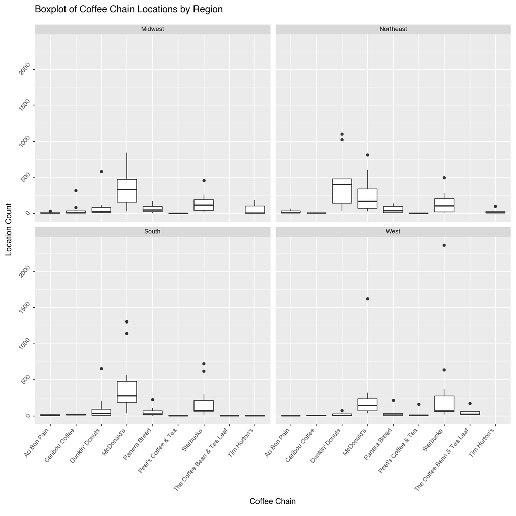

```
<Figure Size: (1000 x 1000)>
```

```python
(ggplot(df3, aes(x = "Coffee Chain", y = "Location Count"))
 + geom_boxplot()
 + theme(figure_size = (10,10), axis_text = element_text(rotation = 50, hjust = 1))
 + facet_wrap("Region")
 + labs(title = "Boxplot of Coffee Chain Locations by Region"))
```

```python
#Sum of all Location Counts by chain, compare to revenue
grouped = df3.groupby("Coffee Chain")
grouped["Location Count"].sum()
```

```
Coffee Chain
Au Bon Pain                     332
Caribou Coffee                  623
Dunkin' Donuts                 6481
McDonald's                    16781
Panera Bread                   2378
Peet's Coffee & Tea             204
Starbucks                     10294
The Coffee Bean & Tea Leaf      248
Tim Horton's                    500
Name: Location Count, dtype: int64
```

```python
#Sum of locations by state, compare to population
grouped2 = df3.groupby("State")
grouped2["Location Count"].sum().sort_values(ascending = False)
```

```
State
California              4585
Florida                 2663
New York                2621
Texas                   2250
Illinois                2095
Massachusetts           1771
Ohio                    1556
Pennsylvania            1440
Michigan                1284
New Jersey              1076
Georgia                 1059
Virginia                1048
Washington               992
Maryland                 902
Minnesota                827
North Carolina           798
Connecticut              745
Arizona                  727
Indiana                  717
Colorado                 657
Tennessee                632
Missouri                 632
Wisconsin                565
Oregon                   510
Kentucky                 420
Nevada                   414
Alabama                  373
Louisiana                373
South Carolina           355
Oklahoma                 316
New Hampshire            297
Kansas                   297
Iowa                     282
Rhode Island             249
Arkansas                 247
Maine                    229
Utah                     211
Mississippi              195
New Mexico               174
Hawaii                   170
District of Columbia     157
Nebraska                 149
West Virginia            146
Idaho                    135
Delaware                 133
Vermont                   76
Montana                   75
Alaska                    57
South Dakota              56
North Dakota              53
Wyoming                   50
Name: Location Count, dtype: int64
```

Although Texas has the second largest population, it is 4th amongst locations for coffee. Vermont has the second smallest population but the 6th least coffee locations

# Automation

Convert your code for Exercises 1-3 above to a function that takes a single argument: the menuism URL. This function should

Scrape the information on state names and corresponding number of store locations on the webpage specified

Extract the name of the company from either the URL specified or the webpage

Return a clean, organized dataset that has three columns: state abbreviation, location count, company name. Company name will likely be repeated on every row.

My code above would need to be tweaked as it is not very robust for a function. The way I extracted the elements and appended them to the dataframe is not repeatable for all urls. The problem that I was facing is that due to the different length of text, I couldn’t extract just the first element for the state name or just the 4th element for the number of locations. Some states are one word and some are 2 so I had to utilize a bunch of different lines to extract just the names.